# Report about insights and displays the visualization(s)produced from my wrangled data Project

- Introduction
- Most favorited Tweets by users
- What are the most common breeds found by the neural network
- Common dog names
- Visualization
- Conclusion

## Introduction

> trustworthy analyses and visualizations for WeRateDogs Twitter data

> Data source `twitter_archive_master.csv` which is cleaned dataset pproduced from my wrangling effort to WeRateDogs Twitter data

```python
import seaborn as sns                          # library i need
import matplotlib.pyplot as plt
import pandas as pd
```

```python
twitter_archive_master=pd.read_csv('twitter_archive_master.csv')  # read Data
```

## Insight 1 (Most favorited Tweets by users)

#### 1- temp datafram contains important coulmns for tihis insights

```python
Temp=twitter_archive_master[{'tweet_id','favorite_count','rate','stage','jpg_url','text'}]
```

#### 2- using `pandas.DataFrame.nlargest` with count of like to find most Most favorited Tweets

```python
top5=Temp.nlargest(5, 'favorite_count')
```

```python
top5
```

|  | favorite_count | tweet_id | jpg_url | rate | stage | text |
| --- | --- | --- | --- | --- | --- | --- |
| 329 | 132810 | 822872901745569793 | https://pbs.twimg.com/media/C2tugXLXgAArJO4.jpg | 1.3 | puppo | Here's a super supportive puppo participating ... |
| 851 | 131075 | 744234799360020481 | https://pbs.twimg.com/ext_tw_video_thumb/74423... | 1.3 | doggo | Here's a doggo realizing you can stand in a po... |
| 59 | 107956 | 879415818425184262 | https://pbs.twimg.com/ext_tw_video_thumb/87941... | 1.3 | Unknown | This is Duddles. He did an attempt. 13/10 some... |
| 432 | 107015 | 807106840509214720 | https://pbs.twimg.com/ext_tw_video_thumb/80710... | 1.3 | Unknown | This is Stephan. He just wants to help. 13/10 ... |
| 112 | 106827 | 866450705531457537 | https://pbs.twimg.com/media/DAZAUfBXcAAG_Nn.jpg | 1.3 | pupper | This is Jamesy. He gives a kiss to every other... |

### most favorited image by users with 132810 like

[figure not shown]

## Insights2 (What are the most common breeds found by the neural network?)

#### 1-temp datafram contains important coulmns for this insight

```python
temp=twitter_archive_master[{'tweet_id','p1','p2'}]
```

#### 2- using `pandas.melt` to make pridictions in one columns

```python
temp2=pd.melt(temp, id_vars=['tweet_id'])
```

#### using 3-`pandas.Series.value_counts` to find most commen breads

```python
temp2.value.value_counts()
```

```
golden_retriever      242
Labrador_retriever    204
Chihuahua             127
Pembroke              115
Cardigan               92
                     ...
desktop_computer        1
hair_slide              1
pot                     1
Egyptian_cat            1
piggy_bank              1
Name: value, Length: 534, dtype: int64
```

## `golden_retriever` is the most common breeds found by the neural network

## Insights3 (Common dog names)

#### using `pandas.Series.value_counts` to know the most commen names

```python
twitter_archive_master.name.value_counts()
```

```
None       577
Unknown     55
Charlie     11
Lucy        10
Oliver      10
          ...
Lacy         1
Eleanor      1
Jiminus      1
Dido         1
Alfy         1
Name: name, Length: 936, dtype: int64
```

## Visualization

```python
sns.set(style="darkgrid")
fig=plt.figure(figsize=(25,20))
```

### What are the Most frequent rating for Images?

#### 1- using `pandas.Series.value_counts` find outliers rate(rating_numerator/ rating denomister)

```python
twitter_archive_master.rate.value_counts()
```

```
1.200000      477
1.000000      431
1.100000      419
1.300000      283
0.900000      151
0.800000       95
0.700000       51
1.400000       40
0.500000       35
0.600000       32
0.300000       19
0.400000       15
0.200000       10
0.100000        4
0.000000        2
0.818182        1
2.700000        1
3.428571        1
0.636364        1
177.600000      1
2.600000        1
42.000000       1
7.500000        1
1.500000        1
Name: rate, dtype: int64
```

### 2- remove outlier using `pandas.DataFrame.query`

```python
temp=twitter_archive_master.query('rate<2')
```

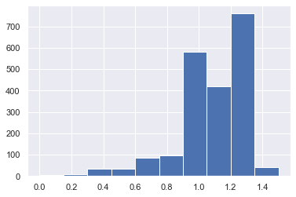

```python
plt.hist(temp.rate)
plt.show()
```

### What is the Most frequent Dog stage

#### 1- explore outliers und unkown stage using `pandas.Series.value_counts`

```python
temp.stage.value_counts()
```

```
Unknown         1748
pupper           209
doggo             67
puppo             23
doggopupper       11
floofer            7
doggopuppo         1
doggofloofer       1
Name: stage, dtype: int64
```

#### 2- remove Unknow stage

```python
temp2=temp.query('stage!="Unknown"')
```

#### 3- draw plot using `seaborn.countplot`

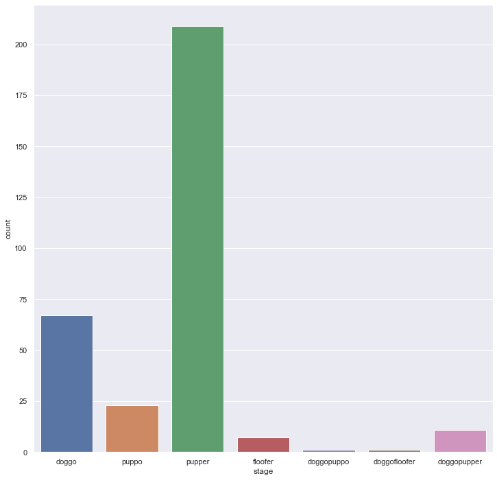

```python
fig, ax = plt.subplots(figsize=(12, 12))
sns.set(style="darkgrid")
ax = sns.countplot(x="stage", data=temp2)
```

## `pupper` is most frequent Dog stage

### Relation between number of retweets and likes of the tweet

#### plot using `seaborn.scatterplot`

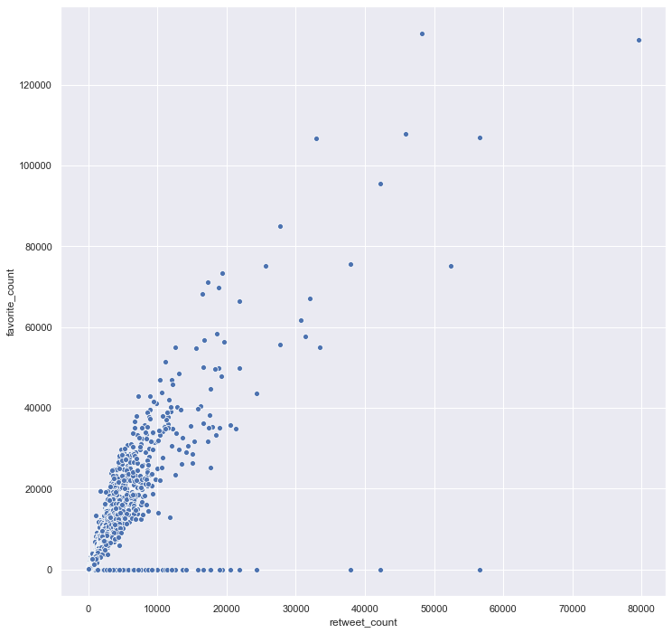

```python
fig, ax = plt.subplots(figsize=(12, 12))
ax=sns.scatterplot(x = "retweet_count", y = "favorite_count", data=twitter_archive_master)
```